# Projeto

2024-04-14

```r
if (!requireNamespace("plot.matrix", quietly = TRUE)) install.packages("plot.matrix")
if (!requireNamespace("dbscan", quietly = TRUE)) install.packages("dbscan")
if (!requireNamespace("ggplot2", quietly = TRUE)) install.packages("ggplot2")
if (!requireNamespace("rpart", quietly = TRUE)) install.packages("rpart")
if (!requireNamespace("rpart.plot", quietly = TRUE)) install.packages("rpart.plot")
if (!requireNamespace("caret", quietly = TRUE)) install.packages("caret")

library(plot.matrix)
library(dbscan)
library(ggplot2)
library(rpart)
library(rpart.plot)
library(caret)
library(dplyr)


plotfigure <<- function(row,dataset)
{
  X = NULL
  if(!is.null(nrow(dataset)))
  {
    X = data.frame(matrix(dataset[row,2:785],nrow=28))
  }
  else
  {
    X = data.frame(matrix(dataset[row,2:785],nrow=28))
  }
  m1 = data.matrix(X)
  plot(m1, cex=0.5)
}
```

# Introdução

A base de dados para o desenvolvimento do trabalho contém imagens de caracteres alfanuméricos manuscritos, incluindo letras maiúsculas e minúsculas, além de dígitos de 0 a 9. Cada imagem tem uma resolução de 28 × 28 = 784 pixeis. O trabalho será realizado para as letras D e F.

```r
train_data <<- read.csv("emnist-balanced-train.csv",sep=",",header = FALSE)
test_data <<- read.csv("emnist-balanced-test.csv",sep=",",header = FALSE)
```

Nas figuras seguintes pode observar-se algumas das possíveis representações da letra D e da letra F.

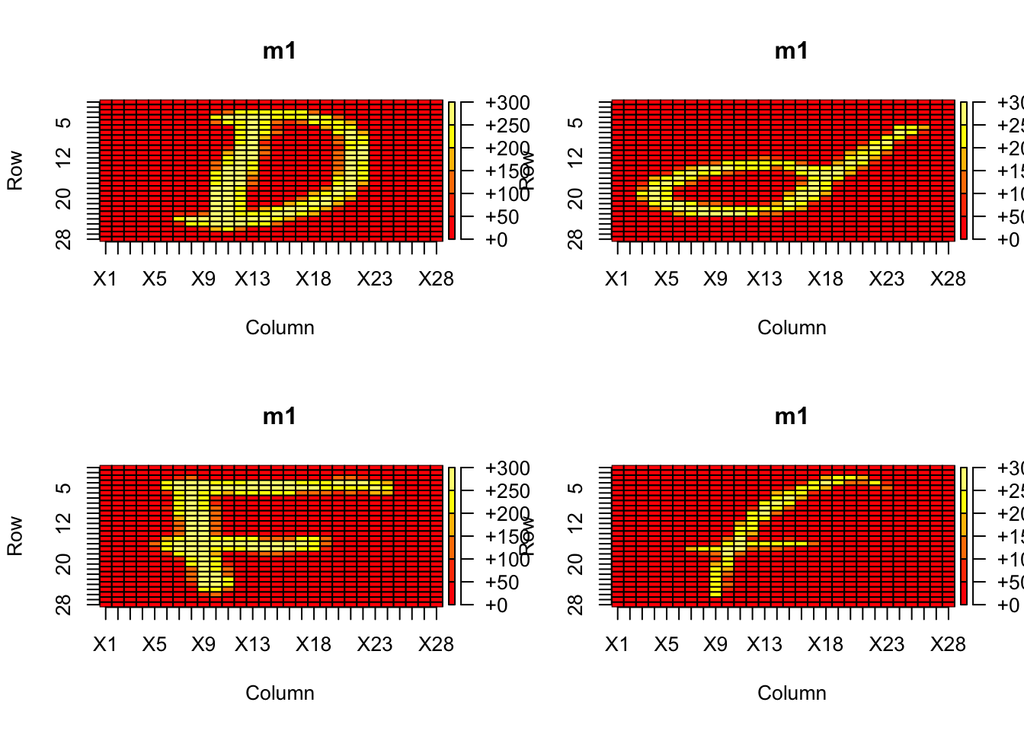

```r
par(mfrow = c(2, 2))

plotfigure(14,train_data)
plotfigure(60,train_data)
plotfigure(13,train_data)
plotfigure(4,train_data)
```

Dado que se pretende apenas trabalhar com as letras D e F, reduziu-se a base de dados inicial para que esta apenas contenha as letras D e F.

```r
label_D <- 13
label_F <- 15

filtered_train_data <- train_data[train_data$V1 %in% c(label_D, label_F), ]
filtered_test_data <- test_data[test_data$V1 %in% c(label_D, label_F), ]

head(filtered_train_data[, 1:5], 5)
```

```
##    V1 V2 V3 V4 V5
## 4  15  0  0  0  0
## 13 15  0  0  0  0
## 14 13  0  0  0  0
## 53 15  0  0  0  0
## 73 13  0  0  0  0
```

# Análise Exploratória

Com o objetivo de distinguir as duas letras, é necessário determinar uma zona de relevância, ou seja, o conjunto de pixeis que determinam com elevada probabilidade se na imagem está representada a letra D ou a letra F.

Com este intuito foi construída uma árvore de decisão, representada na figura seguinte.

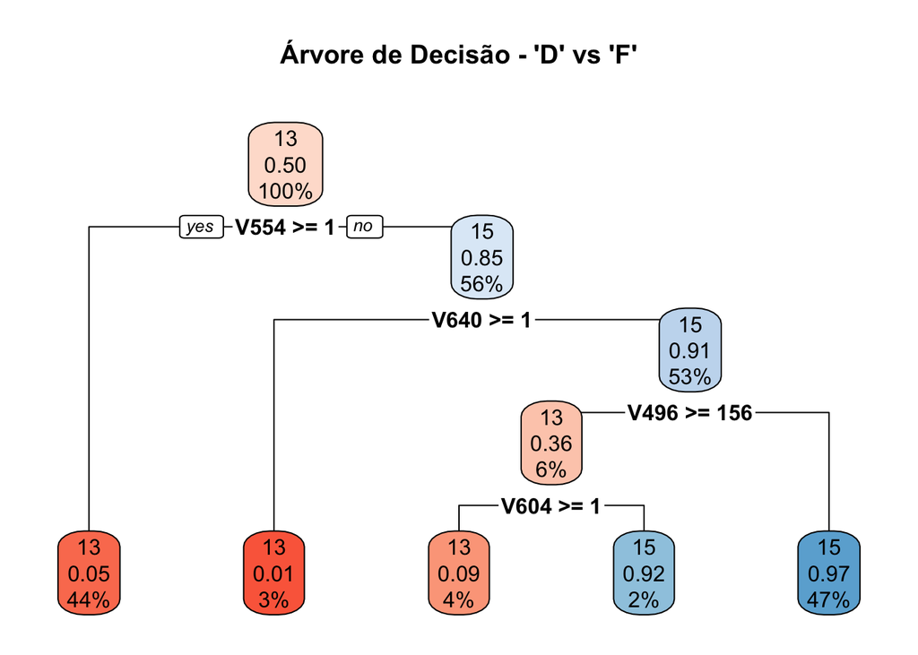

```r
set.seed(123)

modelo_arvore <- rpart(V1 ~ ., data = filtered_train_data, method = "class")

rpart.plot(modelo_arvore, main="Árvore de Decisão - 'D' vs 'F'",
           box.palette = "RdBu")
```

A árvore de decisão indica como pixel mais influente na diferenciação das letras o pixel 554. Se o valor do pixel for superior ou igual a 1, classifica-se a imagem como D. No entanto, se o pixel tiver um valor inferior a 1, o pixel 640 passa a ter influência para classificar a imagem. Isto significa que o pixel 554 é suficiente para classificar a imagem como D, mas não para classificar a imagem como F. A classificação da imagem como a letra F passa por analisar os pixeis 554, 640 e 496.

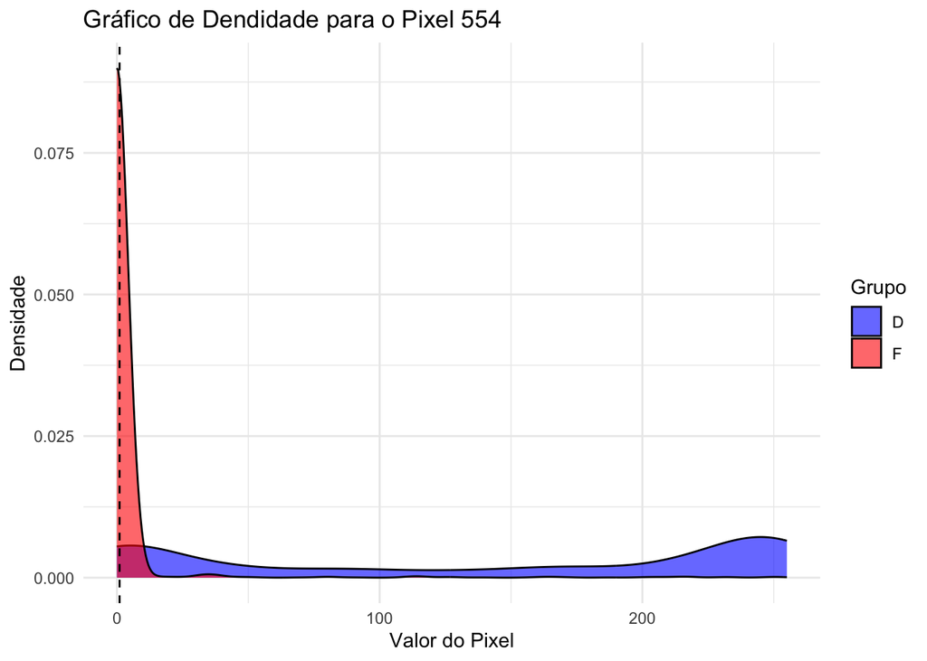

Pela caixa-de-bigodes seguinte, é perceptível que para valores do pixel 554 inferiores a 1, existe uma distinção entre a letra D e F. Podemos observar que para as imagens da letra F, é mais comum o pixel 554 apresentar valores inferiores a 1 e para as imagens da letra D, é mais comum o pixel 554 apresentar valores superiores a 1.

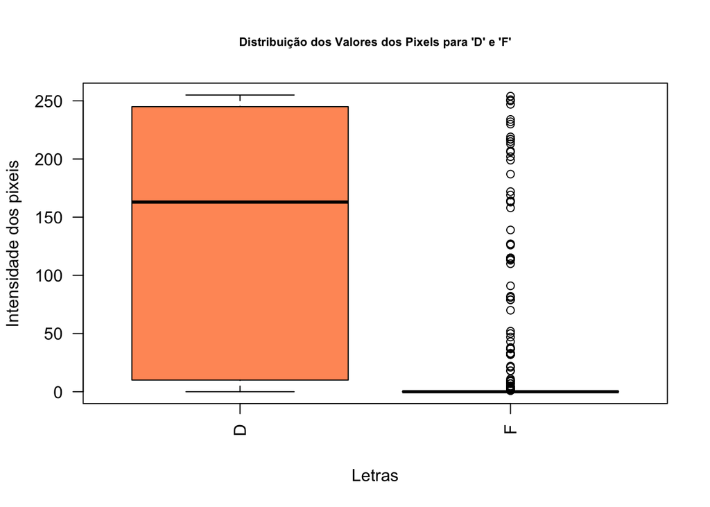

```r
boxplot(as.matrix(filtered_train_data[,554:554]) ~ character_labels,
        col=c("#FF9966", "#996633"),
        las=2,
        xlab="Letras",
        ylab="Intensidade dos pixeis",
        #outline=FALSE
)
title(main = "Distribuição dos Valores dos Pixels para 'D' e 'F'", cex.main = 0.7)
```

[figure not shown]

```r
par(mfrow = c(1, 2))

ggplot(combined_data, aes(x = V640, fill = group)) +
  geom_density(alpha = 0.6) +
  scale_fill_manual(values = c("blue", "red")) +
  theme_minimal() +
  labs(x = "Valor do Pixel", y = "Densidade", title = "Gráfico de Dendidade para o Pixel 554") +
  guides(fill = guide_legend(title = "Grupo")) +
  geom_vline(xintercept = 1, linetype = "dashed", color = "black") +
  coord_cartesian(ylim = c(0, 0.25))
```

[figure not shown]

```r
#-----------------

ggplot(combined_data, aes(x = V496, fill = group)) +
  geom_density(alpha = 0.6) +
  scale_fill_manual(values = c("blue", "red")) +
  theme_minimal() +
  labs(x = "Valor do Pixel", y = "Densidade", title = "Gráfico de Dendidade para o Pixel 554") +
  guides(fill = guide_legend(title = "Grupo")) +
  geom_vline(xintercept = 1, linetype = "dashed", color = "black") +
  coord_cartesian(ylim = c(0, 0.1))
```

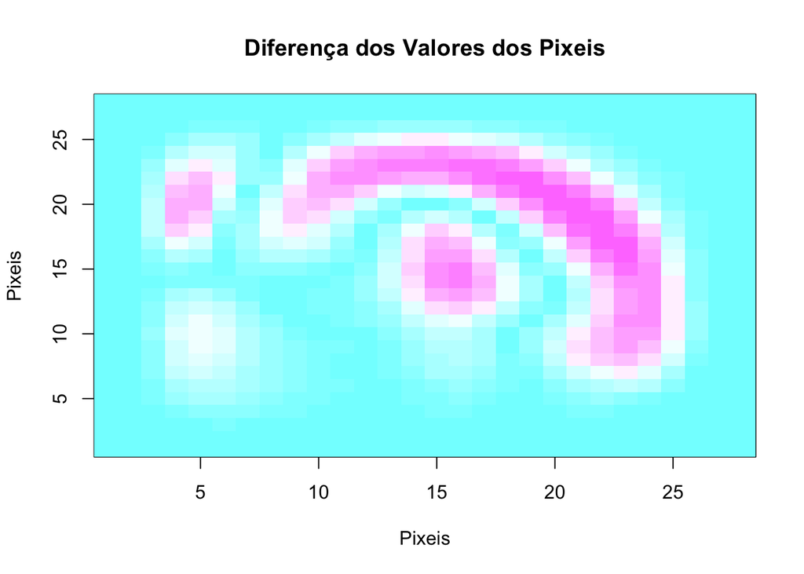

```r
sums_D <- colSums(filtered_train_data[filtered_train_data$V1 == label_D, -1])
sums_F <- colSums(filtered_train_data[filtered_train_data$V1 == label_F, -1])

differences <- abs(sums_D - sums_F)


matrix_dim <- 28
differences_matrix <- matrix(differences, nrow = matrix_dim, ncol = matrix_dim)


image(1:28, 1:28, differences_matrix,
      col = cm.colors(20),
      xlab = "Pixeis", ylab = "Pixeis",
      main = "Diferença dos Valores dos Pixeis")
```